# Pandas-Bootcamp-Part1

### .get() method

Another way to extract values from a Series is the .get() method

```python
#get() also follows Label based indexing like loc
```

```python
labeled_alphabet.get('label_I')
```

```
'i'
```

```python
labeled_alphabet.loc['label_I']
```

```
'i'
```

```python
labeled_alphabet['label_I']
```

```
'i'
```

#### Q: Why should we use get() when we have the other two methods?

get() method has some conveniences to offer

```python
#get() seems to return nothing when we try to access a index label that does not exist
labeled_alphabet.get('label_inexistent')
```

```python
#Infact it is actually returning the object "None"

labeled_alphabet.get('label_inexistent') == None
```

```
True
```

This is because get() supports a default parameter , which by default is assigned to the object "None"

```python
labeled_alphabet.get('label_inexistent' , default = None)
```

This is great because it gives us the opportunity to specify a Custom default value.

- So when a label is not found the msg is displayed

```python
labeled_alphabet.get('label_inexistent' , default = "Could not find the Label")
```

```
'Could not find the Label'
```

```python
#We could index by position as well same like iloc and regular Square bracket indexing
#get() method does not have Slice support
labeled_alphabet.get(8)
```

```
'i'
```

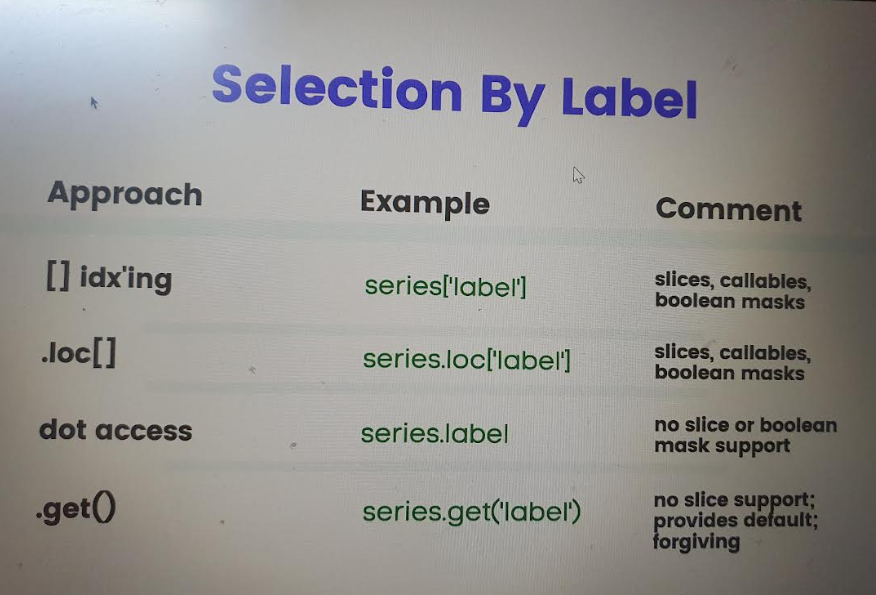

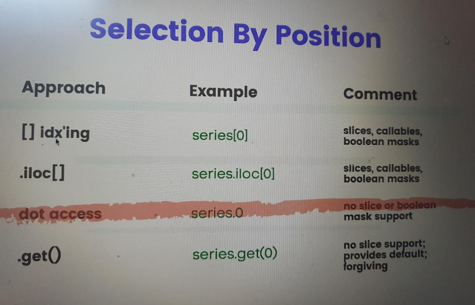

### Skill Challenge

```python
Squares = pd.Series([x*2 for x in range(100)])
```

```python
Squares.head(5)
```

```
0    0
1    2
2    4
3    6
4    8
dtype: int64
```

https://www.udemy.com/course/the-ultimate-pandas-bootcamp-advanced-python-data-analysis/learn/lecture/18239952#overview

```python
#Extract the last three items from the Squares series using square bracket indexing
Squares[-3 :]
```

```
97    194
98    196
99    198
dtype: int64
```

```python
#Repeat step 2 using the tail method
Squares.tail(3)
```

```
97    194
98    196
99    198
dtype: int64
```

```python
#Verify that the Output of Step2 and Step3 are the same using the .equals method
```

```python
step2 = Squares[-3 :]
```

```python
step3 = Squares.tail(3)
```

```python
step2.equals(step3)
```

```
True
```

```python
#This is returning another Series
#This is the element wise comparison
step2 == step3
```

```
97    True
98    True
99    True
dtype: bool
```

### .............................................................................................................